# Safety surveillance and signal refinement

## Table of contents

1. Stages and goals of safety surveillance
2. Study designs
3. Sequential hypothesis tests
4. Safety surveillance methods (maxSPRT)
5. Application of maxSPRT to Finnish register data

## 1: Stages and goals of safety surveillance

Generating, refining and confirming information

### Drug safety

An adverse event is defined as an untoward medical occurrence in a patient administered a pharmaceutical product.

- Rare adverse events related to drugs are often impossible to detect in pre-licensure studies
- Therefore there is an incentive to monitor the safety of a drug post-licensure
- This monitoring is called safety surveillance

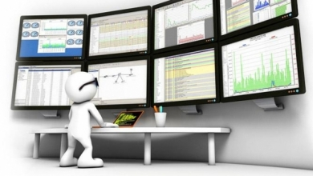

### Safety surveillance

Safety surveillance involves generating, refining and confirming information of possible causal relationships between exposure and event pairs.

- Such information are called safety signals
- Here, the exposure of interest is a **vaccine** product and the events are some unwanted medical conditions (adverse events)
- Surveillance is preferably done in real time and with methods which minimize errors and the sample size

### Three stages of surveillance

Post-licensure safety aims can be classified into three stages:

1. **Signal identification**: Involves detecting unexpected adverse events and considers a large number of events
2. **Signal refinement**: Attempts to address a few specified hypothesis about suspected product-event pairs based on biological plausibility
3. **Signal confirmation**: Involves a more in depth follow-up of a generated signal

We will concentrate on **signal refinement**.

### Focus on the refinement stage

A signal is information of a **possible** causal relationship between the exposure and the event.

- We will focus on safety surveillance in the signal refinement stage from a **methodological point of view** and assume that a biologically plausible exposure - event pair is already given
- The goal is to design a study and test for a statistical association between the exposure and the event. A signal is generated if an association is found.
- A safety surveillance method is a combination of data collection, study design and statistical hypothesis test(s)

### Goals related to safety surveillance

A natural goal of safety surveillance is to minimize false positive and false negative signals

- In statistical terms, minimizing false negatives is equivalent to maximizing power
- Since observations are unwanted events, another natural goal is to minimize the expected sample size
- Usually more samples lead to fever errors (higher power)…

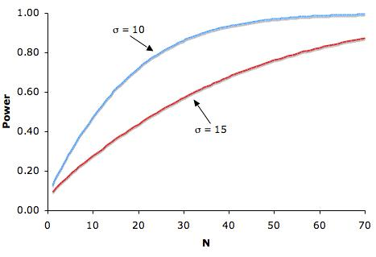

### How to achieve the goals?

The goal is to minimize the errors and the sample size, but usually less samples lead to more errors. Things to concider:

- The study design should avoid biases in the sample to minimize errors
- The statistical test should make it possible to stop early if there is enough evidence of an association, while simultaniously keeping the error rates low

A solution is to use real-time monitoring and **sequential testing** where a hypothesis test is performed as often as possible. **Self-controlled study designs** can help to avoid biases.

## 2: Study designs

Avoid a biased sample

### Options

The following study designs could in theory be concidered for safety surveillance:

- **Cohort**: Groups of exposed and non-exposed individuals are followed forward in time. Incidences of events are compared between the groups.
- **Case-control**: Individuals with events are matched to individuals without events using variables such as age and gender. Proportions of exposure are compared.
- **Self controlled**: For each exposed individual, a risk interval and a non-risk interval is defined. Incidences during the intervals are compared

### Self-controlled designs: an example

- In self-controlled designs, the assignment to the case or control group depends on the time of the event
- Events during a risk period are classified as cases and events during a non-risk period as controls
- The case-crossover design (CCR) is a simple example of a self-controlled design

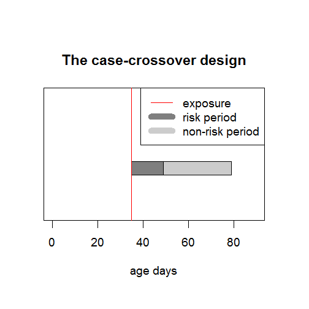

### The study design matters

Recent safety surveillance studies have generated multiple **false** positive signals (signals that could not be confirmed), due to:

1. **changes in coding**
2. **inappropriate control groups**
3. **uncertainty or changes in baseline incidence**
4. **Type I errors**.

Reason 4 relates to the statistical method used. Reasons 1-3 relate to the study design and they can be avoided with a self-controlled design.

### Self controlled designs: properties

The major weakness of the other designs is that confounders can affect the probability of exposure and result in bias.

- The risk of the above is minimal in a self-controlled design because each case essentially acts as their own control
- However, possible time varying confounders must be explicitly included in the model and the **selection of proper time intervals is crucial**
- The self-controlled designs retain relatively high power despite using little data (usually only cases)

### The case-crossover design (1)

We will assume that the rate ratio is the **same for all** individuals, \( RR_i = RR \).

### The case-crossover design (2)

By conditioning on the total number of observations *n*, the distribution of the total number of cases \( k \) no longer has any dependency on the baseline incedences.

\[ k | n \text{ ~ } Bin(n, p = \frac{RR}{z + RR}) \]

\[ \text{where } z=\frac{length(ctrl)}{length(case)} \]

- This is typical for the self-controlled designs: The **individual incidences cancel out** from the statistical model. For this reason the design is said to implicitly control for all non time-varying confounders.

### The case-crossover design (3)

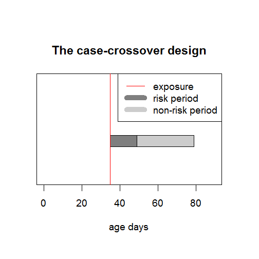

*The outcome of an event classified as a case or a control is a Bernoulli trial. The probability of the outcome depends on the lengths of the risk and non-risk intervals.*

### Study design conclusions

Ultimately all epidemiological study designs do the same thing: compare some group of individuals to another group of individuals

- In self-controlled designs the assignment to the case or control group depends only on the time of the event
- Hence in self-controlled designs it is impossible to have non time-related selection bias in the case or control groups
- Therefore using a self-controlled design **can help to minimize errors** in safety surveillance

## 3: Sequential hypothesis testing

Minimize the sample size

### How to minimize the sample size?

In the setting of vaccine safety surveillance, every observation is some unwanted event.

- Therefore there is incentive to minimize the expected sample size when an association exists
- This is can be achieved by utilizing the data as often as possible
- A procedure called the sequential probability ratio test (**SPRT**) minimizes the expected sample size when testing two simple hypothesis
- SPRT is a **sequential hypothesis test**

### A sequential hypothesis test

Generally, a sequential test of a statistical hypothesis is a test procedure which gives a rule of making one of three possible decisions at a single trial of the experiment:

1. **Accept** \( H_0 \)
2. **Reject** \( H_0 \)
3. **Continue** the experiment by making an additional observation.

Sequential hypothesis testing was developed by Abraham Wald during the II World War.

### Sequential probability ratio test (1)

The sequential probability ratio test (SPRT) is the **most powerfull** sequential test for testing two simple hypothesis.

- SPRT reduces the expected sample size by ~50% compared to a regular hypothesis test with similar error rates
- SPRT uses the likelihood ratio \( LR \) as the test statistic

\[ LR = \frac{L(RR | H_1)}{L(RR | H_0)} \]

- The likelihood function \( L() \) is a function of the interesting parameter (RR) and it contains the statistical model for the observations

### Sequential probability ratio test (2)

- The test statistic (LR) is calculated whenever a new observation arrives.
- The test statistic is then compared to critical values to make a desicion
- High values are critical to the null hypothesis.
- If the test statistic exceeds a boundary, the test terminates with a decision

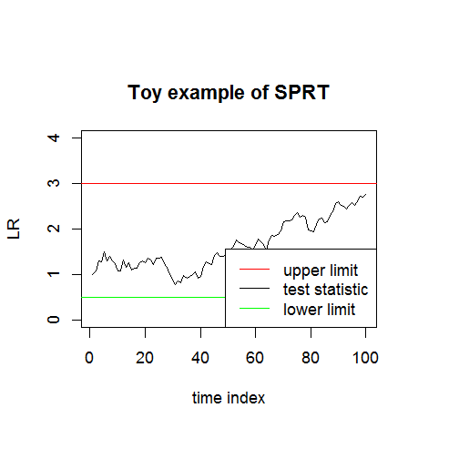

### Setting the hypothesis for safety surveillance

When the objective is to find evidence of an association between an exposure and an event, the null proposition is a state of no association.

- The most natural alternative hypothesis however is composite: some positive association. This can be stated with the rate ratio \( RR \) as follows:
- \( H_0: RR = 1 \)
- \( H_1: RR > 1 \)

In this case an extension of SPRT called the **maxSPRT** can be used to perform sequential hypothesis testing.

### maxSPRT

maxSPRT is a sequential hypothesis test which uses the maximized likelihood ratio as a test statistic.

\[ LR = max \frac{L(RR > 1)}{L(RR = 1)} \]

- maxSPRT uses **one critical value \( c \)**: if at any point \( LR \geq c \), then \( H_0 \) is rejected
- maxSPRT uses an **upper boundary N** on the sample size: if \( n > N \), then \( H_0 \) is accepted.

### The desicion rule of maxSPRT

More formally the maxSPRT test proceeds as follows:

1. First define a critical value \( c \) and an upper boundary for the sample size \( N \)
2. After observation \( i = 1, .., N - 1 \) do
   - if \( LR_i \geq c \) stop, reject \( H_0 \)
   - otherwise continue
3. After observation \( N \) do
   - if \( LR_N \geq c \) stop, reject \( H_0 \)
   - otherwise accept \( H_0 \)

### The critical values of maxSPRT

SPRT type tests solve the problem of multiple testing by concidering the joint distribution of the test statistic.

- The critical value \( c \) is computed such that the total probability of generating a false positive signal is some defined \( \alpha \):

\[ P(LR_i \geq c \text{ for some } i = 1, .., N) = \alpha \]

- Computing the critical values of the test is tricky and requires further research for most statistical models
- For the **binomial** and Poisson models a solution exists. A Markov chain approach can be applied in the binomial case.

### Data accumulation matters

The SPRT type statistical tests assume that the null hypothesis is tested at **every** new observation.

- If this assumption is not met, the critical values of the test should be affected
- If data becomes available in groups, **group sequential methods** should be used instead
  - If the size of the groups is known, the solution for computing the critical values of the test is similar to the SPRT type tests
  - If the size of the groups is random, approaches such as alpha spending should be used instead

### Sequential testing: conclusions

SPRT type sequential testing is only suitable if **new data is available often enough** because it assumes that the test can terminate at every new observation.

- The performance of sequential tests is optimized when all available data is utilized as frequently as possible
- Sequential testing can **reduce** the expected sample size by ~50% compared to regular hypothesis tests with similar error rates
- The chosen upper limit \( N \) in maxSPRT affects the power and the critical value of the test (higher \( N \) -> higher power and higher \( c \))

## 4: Safety surveillance methods

Combining a study design and statistical hypothesis testing

### Continuous safety surveillance

A safety surveillance method can be viewed as a combination of

- **data collection**
- **study design**
- **statistical hypothesis test(s)**.

We will assume that data is actively collected and accumulates as a **stream**, making it possible to use sequential testing. The goal is to **refine** an identified signal.

### Binomial maxSPRT (1)

By combining a self-controlled design and a maxSPRT sequential hypothesis test, we get a safety surveillance method called the Binomial maxSPRT (**B-maxSPRT**).

- The likelihood function is

\[ L(RR |n, k, z) = \frac{n!}{k ! (n - k)!} \cdot (\frac{RR}{z + RR})^k \cdot (\frac{z}{z + RR})^{n - k} \]

- The likelihood ratio test statistic is

\[ LR = max \frac{L(RR > 1 | n, k, z) }{L(RR = 1| n, k, z) } = \underset{RR>1}{max} \frac{ (\frac{RR}{z + RR})^k \cdot (\frac{z}{z + RR})^{n - k} }{ (\frac{1}{z + 1})^k \cdot (\frac{z}{z + 1})^{n - k} } \]

### Binomial maxSPRT (2)

For computational reasons, it is conventient to operate with the log likelihood ratio instead.

- Maximizing the log likelihood ratio can be done by finding the maximum likelihood estimate for the parameter \( RR \)
- Since we are not interested in cases where \( RR < 1 \), we should use \( \hat{RR} = max\{1, \frac{z \cdot k}{n - k} \} \), and so

\[ LLR = log(LR) = log \left( \frac{ (\frac{\hat{RR}}{z + \hat{RR}})^k \cdot (\frac{z}{z + \hat{RR}})^{n - k} }{ (\frac{1}{z + 1})^k \cdot (\frac{z}{z + 1})^{n - k} } \right) \]

### Exploring the properties of maxSPRT

You can experiment with the performance of maxSPRT with the [maxSPRT Shiny-app](http://shiny.app.thl.fi/maxSPRT/), available in the THL intranet

- Binomial and Poisson models
- Computations for power and expected time to signal for user defined target populations
- Implementations for simulated data

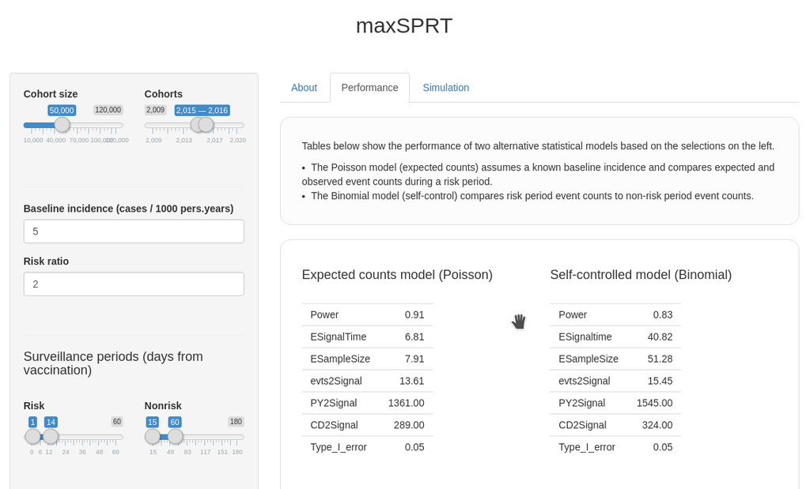

### Safety surveillance methods: conclusions

A safety surveillance method is a combination of data collection, study design and hypothesis testing.

- By combining a simple self-controlled design with maxSPRT sequential testing, we get the B-maxSPRT surveillance method for stream type data
- Critical values for the test statistic can be computed using a Markov chain approach implemented in the Sequential R-package
- The Sequential package can also be used for power calculations

## Application of B-maxSPRT

exposure: PCV, Rota or MPR vaccination  
event: Fever seizures

### About the experiment

In this application, B-MaxSPRT was retrospectively applied to Finnish register data. We pretend as if we are observing new data daily.

- **Exposure**: PCV, Rota or MPR vaccination
- **Events**: fever seizure related hospitalizations
- It is established that MPR vaccination causes acute fever seizures. This relationship has also been shown using the Finnish register data.

B-maxSPRT was **expected to generate** a signal related to MPR, but not PCV or Rota.

### Data

The vaccinations of interest are the first doses of MPR, PCV and Rota vaccinations for children under 2 years of age born during 2010 - 2014.

- For the MPR group, the 2014 cohort was excluded because the expected age at vaccination is higher and no sufficient data was yet available.
- The possible adverse events of interest are hospitalizations with [icd-10 diagnosis codes related to fever seizures.](https://terho.thl.fi/wiki01/display/rokobiom/Case-series+analyysi)

### ICD-10 codes

The following icd-10 codes were considered:

- **A**. A858 *Other specified viral encephalitis*, A86 *Unspecified viral encephalitis*, A87 *Viral meningitis*, A88 *Other viral infections of central nervous system, not elsewhere classified*
- **G**. G038 *Meningitis due to other specified causes*, G039 *Meningitis, unspecified*, G04 *Encephalitis, myelitis and encephalomyelitis*, G05 *Encephalitis, myelitis and encephalomyelitis in diseases classified elsewhere*
- **R**. R291 *Meningismus*, R55 *Syncope and collapse*, R560 *Febrile convulsions*, R568 *Other and unspecified convulsions*

### Age intervals and observation periods

For both vaccinations and hospitalizations, age intervals that cover first dose vaccinations of the chosen vaccines were considered:

- MPR: 250 - 650 days
- Rota: 30 - 140 days
- PCV: 60 - 200 days

The case interval is **1-14** days after vaccination and control interval **15-42** days after vaccination. This includes an assumption that the possible effect of the vaccination is transient.

### Surveillance conditions (1)

The safety surveillance method used was B-maxSPRT. The parameters \( N \), \( c \) and \( \alpha \) were defined as:

- \( N \): This was taken to be the expected number of events during the retrospective time period (2010-) under \( H_0 \) for each age group, according to an estimated baseline incidence.
- Type I error (false positive) probability was chosen to be \( \alpha = 0.05 \).
- \( c \): Exact critical values were computed using the Sequential R-package

### Surveillance conditions (2)

Below are the parameters which define the stopping conditions of the maxSPRT method for each vaccine group.

|  | N | c | power | alpha |
| --- | --- | --- | --- | --- |
| MPR | 380 | 3.78 | 0.92 | 0.05 |
| ROTA | 258 | 3.69 | 0.80 | 0.05 |
| PCV | 253 | 3.68 | 0.79 | 0.05 |

The power is calculed using an assumed rate ratio of 1.5.

### Surveillance results, MPR

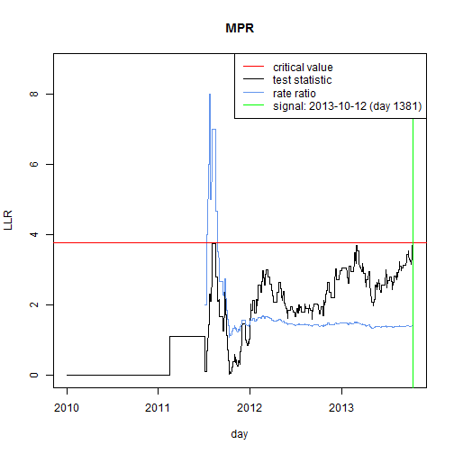

### Surveillance results, Rota

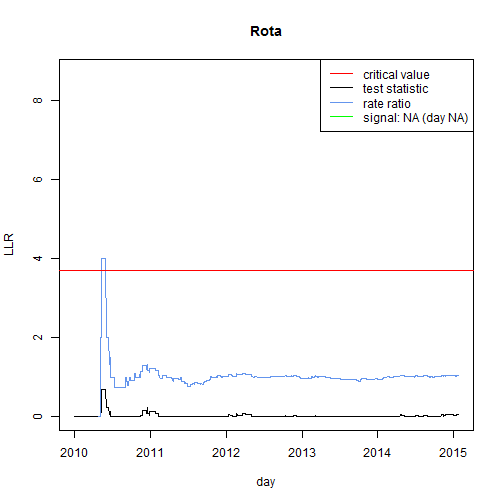

### Surveillance results, PCV

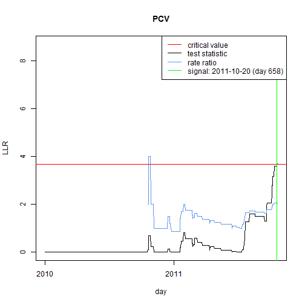

### Surveillance results summary

A signal was generated for MPR and PCV and not generated for Rota.

|  | signal | day | LLR | cases | controls | n | RR |
| --- | --- | --- | --- | --- | --- | --- | --- |
| MPR | TRUE | 1381 | 3.80 | 102 | 142 | 244 | 1.44 |
| Rota | FALSE | 1850 | 0.08 | 89 | 169 | 258 | 1.05 |
| PCV | TRUE | 658 | 3.71 | 29 | 28 | 57 | 2.07 |

Notably the signal generated for PCV came with relatively low \( n \) concidering the number of days passed.

### More surveillance results, MPR

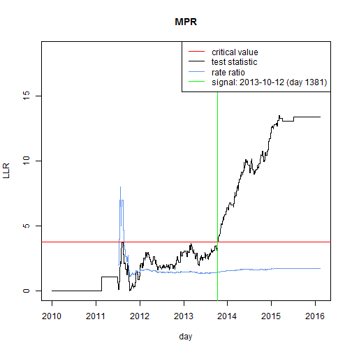

### More surveillance results, PCV

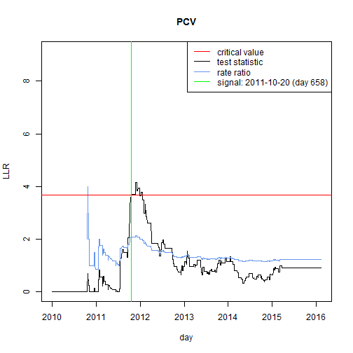

### Surveillance conclusions

The surveillance method generated an expected signal related to MPR, but also an unexpected signal related to PCV

- However, further surveillance showed that when using all the available data, the estimate of the rate ratio for the PCV group was close to 1 (1.22)
- Therefore the signal related to PCV is likely to be a type I error, which were expected to occur 5% of the time for each exposure event pair.

## Thank you!

### Literature

- Jennison (2000): Group Sequential Methods with Applications to Clinical Trials
- Kulldorff (2011): A Maximized Sequential Probability Ratio Test for Drug and Vaccine Safety Surveillance
- Leite (2016): Near Real-time Vaccine Safety Surveillance Using Electronic Health Records - a Systematic Review of the Application of Statistical Methods
- Maclure (1991): The Case-Crossover Design: A Method for Studying Transient Effects on the Risk of Acute Effects
- McClure (2008): Comparison of Epidemiologic Methods for Active Surveillance of Vaccine Safety
- Nelson (2015): Methods for Observational Post-licensure Medical Product Safety Surveillance
- Wald (1945): Sequential Tests of Statistical Hypothesis